# simplified_likelyhood_neftel_presentation

2023-09-24

## Still simplified but on neftel data

As a next step we want to use some more complicated data to cluster cells in, but we leave target gene clustering for later.

```r
#load sampled data
neftel_path <- file.path(dirname(master_folder), "datasets_sctargettranslator", "Neftel2019", "r_files", "neftel_seurat_group1.rds")
print(paste("Loading Neftel data from: ", neftel_path))
```

```
## [1] "Loading Neftel data from:  C:/Users/Filip/repos/datasets_sctargettranslator/Neftel2019/r_files/neftel_seurat_group1.rds"
```

```r
Neftel_g1 <- readRDS(file = neftel_path)

Neftel_g1 <- SetIdent(Neftel_g1, value='malignant')

#get malignant expression on proper form
z_g1<-GetAssayData(Neftel_g1, slot='scale.data')
is_malignant <- ("yes" == Neftel_g1@meta.data$malignant) + 0
metaData<-Neftel_g1@meta.data$sample


out<-scregclust_format(z_g1)

sample_assignment<-out[[2]]
is_predictor<-out[[3]]

#put some stuff in order
z_g1_ordered <- z_g1[order(is_predictor),order(is_malignant)]
metaData     <- metaData[order(is_malignant)]
is_predictor <- is_predictor[order(is_predictor)]
is_malignant <- is_malignant[order(is_malignant)]

rm(z_g1)
rm(Neftel_g1)


# True cell clustering here is the malignancy for example
true_cell_clust <- is_malignant + 1
n_cell_clusters<- length(unique(true_cell_clust))
```

Now we simplify the dataset a bit to make it easier to work with. We subset the amount of cells, select regulators, and find target genes withsome correlation to these regulators. Hopefully we can build some linear models from these pairs.

```r
cell_sample <- c(sample(which(is_malignant==0), 1500 ),sample(which(is_malignant==1), 1500 ) )
# cell_sample <- 1:length(is_malignant)

#optional line to make next few lines not take forever
cols2keep <- sample(cell_sample,100, replace = F)



# initial_cell_clust <- sample(1:n_cell_clusters, n_cells, replace = T)

#optional: slice out some rows for efficiency
dim(z_g1_ordered)
```

```
## [1]  3000 13567
```

```r
regulator_vars <- sapply(which(is_predictor==1), function(i) var(z_g1_ordered[i,cols2keep]))

#pick out top 2 variance regulator genes
high_variance_regulators <- which(regulator_vars >= sort( regulator_vars, decreasing = T)[2])

#shift to correct index in entire dataset
high_variance_regulators <- high_variance_regulators + sum(is_predictor == 0)

rm(regulator_vars)
# target_vars <- sapply(which(is_predictor==0), function(i) var(z_g1_ordered[i,]))

#pick out chich targets are highly correlated with either of the chosen regulators
target_vars <- sapply(which(is_predictor==0), function(i) max(abs(cor(t(z_g1_ordered[c(i,high_variance_regulators),cols2keep]))[1,c(2,3)])))

#pick out top 2 variance target genes
high_corr_targets <- which(target_vars >= sort( target_vars, decreasing = T)[2])

rm(target_vars)
```

Next we permute our true cluster labels, hopefully our method will find its way back to these

```r
#first variant simplified_biclust()
max_iter <- 50


#find initial cluster labels
true_cell_clust_sample <- true_cell_clust[cell_sample]
n_target_gene_clusters <- 1 #we are not clustering target genes for now

# Kod för att flytta % av cellerna i varje kluster till ett annat kluster.
disturbed_initial_cell_clust <- true_cell_clust_sample
disturbed_fraction <- 0.15
for(i_cluster in 1:n_cell_clusters){
  indexes_of_cluster <- which(true_cell_clust_sample == i_cluster)
  some_of_those_indexes <- sample(indexes_of_cluster, size=as.integer(length(indexes_of_cluster)*disturbed_fraction), replace = F)
  disturbed_initial_cell_clust[some_of_those_indexes] <-
    sample(c(1:n_cell_clusters)[-i_cluster],
           size=length(some_of_those_indexes), replace=T)
}


cell_cluster_history <- cbind(true_cell_clust_sample, disturbed_initial_cell_clust)
colnames(cell_cluster_history) <- c("True allocation", "Disturbed allocation")
```

next we actually set our data set, some important cariables, and structure how we will keep track of cluster allocations over iterations

```r
dat <- t(z_g1_ordered[c( high_corr_targets, high_variance_regulators), cell_sample])
ind_targetgenes <- c(1,2)
ind_reggenes    <- c(3,4)
dim_(dat)
```

```
## [1] "This matrix has dimensions: 3000 rows, and 4 columns."
```

```r
initial_clustering <- disturbed_initial_cell_clust
dim_(initial_clustering)
```

```
## [1] "This vector has length: 3000"
```

```r
#set up some variables
n_cell_clusters = length(unique(initial_clustering))
# n_target_genes = ncol(dat) - sum(is_predictor==1)
# n_regulator_genes = sum(is_predictor==1)
n_target_genes = 2
n_regulator_genes = 2


#set up cluster history
initial_column_padding <- ncol(as.matrix(initial_clustering)) + 1  # +1 Because we have an index column that is not an index column it's an ID column
cell_cluster_history <- data.frame(matrix(NA, nrow = nrow(as.matrix(initial_clustering)), ncol = max_iter + initial_column_padding))
colnames(cell_cluster_history) <- c("Cell ID", 'Initial clustering', paste0("Iteration ", 1:max_iter))
cell_cluster_history[, 'Cell ID'] <-1:length(initial_clustering)  # Set cell names
cell_cluster_history[, 'Initial clustering'] <- initial_clustering


#preallocate all like matrices for later analysis if feasible
likelyhood_all <- vector("list", length = max_iter)
#set flag for breaking out of the loop.
stop_iterating_flag = F

current_cell_cluster_allocation <- initial_clustering
```

Now, let’s walk through one iteration.

We start with running some linear models, this would conceptually correspond to running scregclust, which fits a much more sophisticadet but still fundamentally linear set of models.

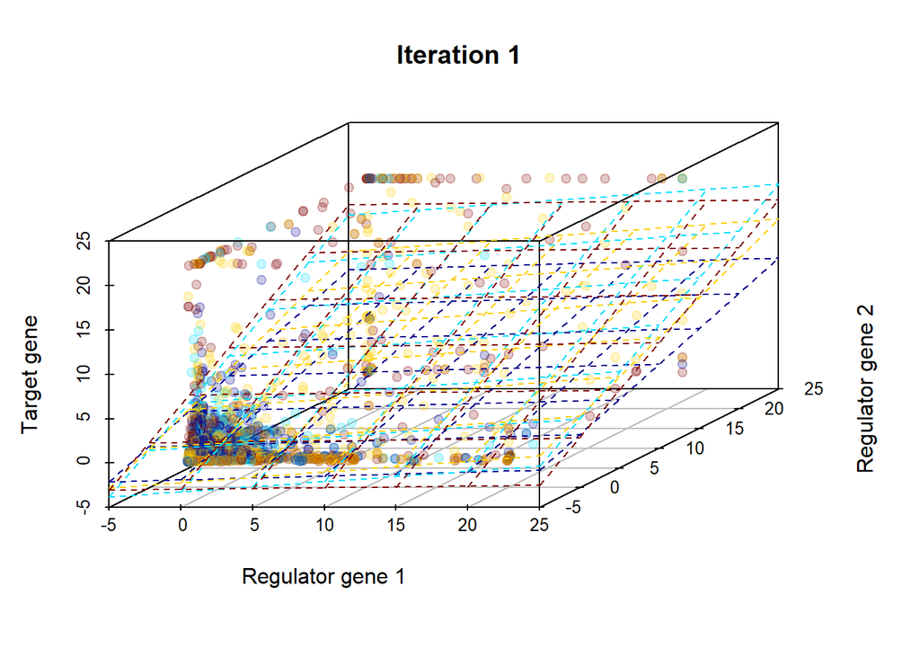

```r
i_main <- 1 #future iteration variable, this is the first iteration

models <- vector("list", length = n_cell_clusters) #allocate list of models

#corresponds to running screg
for(cell_cluster in 1:n_cell_clusters){
  current_rows <- which(current_cell_cluster_allocation == cell_cluster)
  models[[cell_cluster]] <- lm(dat[current_rows, ind_targetgenes] ~ dat[current_rows, ind_reggenes])
}
plot_lm_planes(dat, current_cell_cluster_allocation, ind_reggenes, ind_targetgenes, n_cell_clusters, title=paste("Iteration", i_main))
```

Now that we have some models fit these initial cell clusters, we calculate the likelyhood for each cell belonging to a cluster, along with a penalty.

```r
  #for all cells, calculate the predicted  likelythingy for all cell clusters.
  like <- matrix(0, nrow = nrow(dat), ncol = n_cell_clusters)

  # Calculate the residual target gene variance for each gene and cluster
  INV_TARGET_GENE_RESIDUAL_STD <-  matrix(0, nrow = n_target_genes, ncol = n_cell_clusters)

  lambda <- 0.1 #shrinkage parameter that can  be tuned

  PENALTY <- matrix(0, nrow = 1, ncol = n_cell_clusters)

  #First we calculate the denominator used in the likelyhood ie the variance of the
  #residuals per target gene, restricted to the cells in the respective cell clusters

  #since the penalty doesn't use information about each cell but rather each cluster,
  # we also calculate this here.

  for(cell_cluster in 1:n_cell_clusters){

    #variables to keep track of which cells belong to the current cluster
    intercept_and_regulatorgenes <- as.matrix(cbind(rep(1,nrow(dat)),dat[,ind_reggenes]))  #
    current_rows <- which(current_cell_cluster_allocation == cell_cluster)

    #Calculate the residuals for the current model.
    std_of_residuals_of_target_genes_temp <- dat[current_rows,ind_targetgenes] -
                                               (intercept_and_regulatorgenes[current_rows,] %*%  models[[cell_cluster]]$coefficients)
    #get the std of each target genese variance of residusals, store their reciprocals
    INV_TARGET_GENE_RESIDUAL_STD[,cell_cluster]  <- 1/diag(sqrt(var(std_of_residuals_of_target_genes_temp)))

    #Calculate the penalty for each cluster. Smaller is better.
    #In the real thing this will punish models from scregclust that use bigger and more
    #coefficients
    PENALTY[cell_cluster] <- lambda * sum(abs(models[[cell_cluster]]$coefficients)) # *  INV_TARGET_GENE_RESIDUAL_STD[,cell_cluster] )
  }

  for(cell in 1:nrow(dat)){
    for(cell_cluster in 1:n_cell_clusters){
      # #bug fix hack: remove NA coefficients
      # if(any(is.na(models[[cell_cluster]]$coefficients))){
      #   NA_coeffs <-  unname(which(is.na(models[[cell_cluster]]$coefficients)))
      #   S_ERR <- (dat[cell,1] - as.vector(c(1,dat[cell,c(-1, -NA_coeffs)])) %*% models[[cell_cluster]]$coefficients[-NA_coeffs])^2
      # }

      #calculate numerator for likelyhood
      SQUARED_ERROR <- (dat[cell,ind_targetgenes] - as.vector(c(1,dat[cell,ind_reggenes])) %*% models[[cell_cluster]]$coefficients)^2

      #calculate likelyhood and add penalty. smaller is better
      like[cell,cell_cluster] <- SQUARED_ERROR %*% INV_TARGET_GENE_RESIDUAL_STD[,cell_cluster] +
        PENALTY[cell_cluster]
    }
  }


  likelyhood_all[[i_main]] <- like
```

Now that we have this gathered, we can update out cell cluster assignment.

```r
 #update cluster allocations
  updated_cell_clust <-  sapply(1:nrow(like), function(row) which.min(like[row,]))

  # If there is only 1 cell left in a cell cluster it doesn't work
  # Move that cell to the biggest cell cluster.
  updated_cell_clust_table = data.frame(table(updated_cell_clust))

  for(i_cell_cluster in 1:n_cell_clusters){
    if (length(which(updated_cell_clust==i_cell_cluster)) == 1){
      updated_cell_clust[which(updated_cell_clust==i_cell_cluster)] = which.max(updated_cell_clust_table$Freq)
    }
  }

  # Update data in cell_cluster_history
  cell_cluster_history[, i_main + initial_column_padding] <- updated_cell_clust
```

When we have updated cluster assignment, then we check for convergence and possibly stop.

```r
  # Compare clusters with with previous iterations so we can exit if we seen this allocation before
  for(prev_clustering in ((i_main-1):0) ){
    print(paste0('Comparing with iteration ', prev_clustering))
    if(RI(updated_cell_clust,cell_cluster_history[,prev_clustering + initial_column_padding]) == 1){
      print("Cell clustering from iteration same as some previous iteration. Exiting.")
      print(paste0("RI of ",
                   RI(updated_cell_clust, cell_cluster_history[,prev_clustering + initial_column_padding]),
                   " when comparing iteration ", i_main," to iteration ", prev_clustering))
      stop_iterating_flag = T
      break
    }
  }
```

```
## [1] "Comparing with iteration 0"
```

```r
  if(stop_iterating_flag == T){
    # Clean up cluster history
    cell_cluster_history <- cell_cluster_history[ , colSums(is.na(cell_cluster_history))==0, drop=FALSE]
    # Stop iterations/exit function
    break
  }

  current_cell_cluster_allocation <- updated_cell_clust

  # Handle case where cell cluster disappeared
  unique_cell_cluster_ids <- sort(unique(updated_cell_clust))
  if (length(unique_cell_cluster_ids)<n_cell_clusters){
    n_cell_clusters = length(unique_cell_cluster_ids)
    updated_cell_clust <- mapvalues(updated_cell_clust, from = unique_cell_cluster_ids, to = 1:n_cell_clusters)
    n_target_gene_clusters <- n_target_gene_clusters[unique_cell_cluster_ids]
  }
```

And if we don’t stop, we keep iterating.

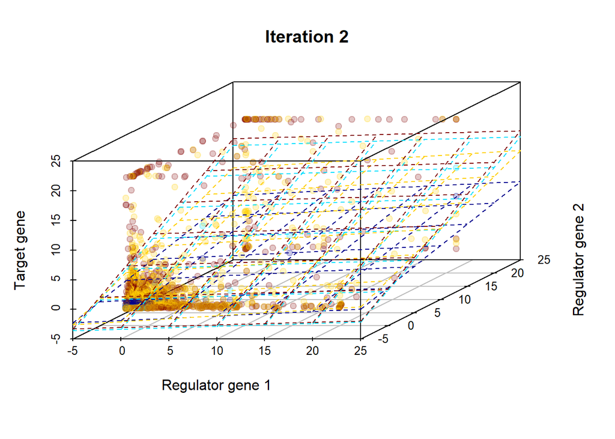

```
## [1] "Comparing with iteration 1"
## [1] "Comparing with iteration 0"
```

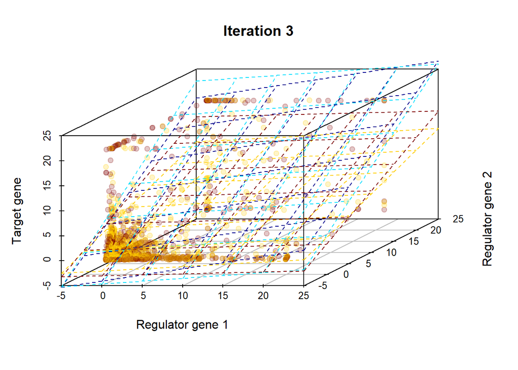

```
## [1] "Comparing with iteration 2"
## [1] "Comparing with iteration 1"
## [1] "Comparing with iteration 0"
```

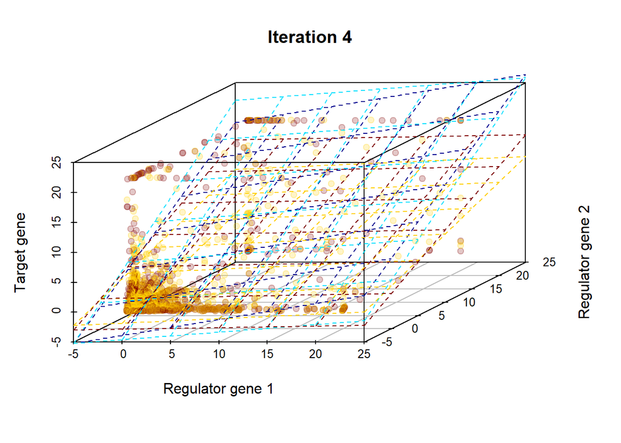

```
## [1] "Comparing with iteration 3"
## [1] "Comparing with iteration 2"
## [1] "Comparing with iteration 1"
## [1] "Comparing with iteration 0"
```

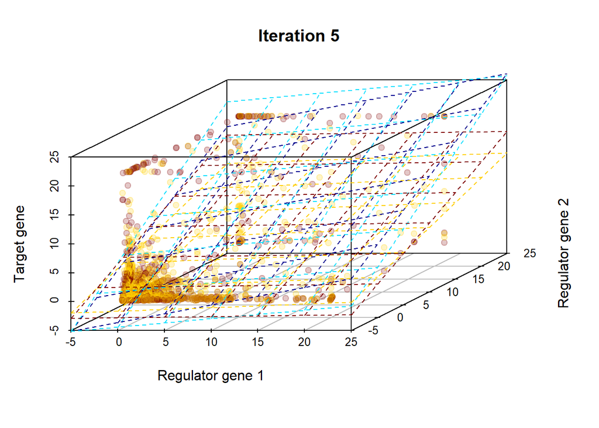

```
## [1] "Comparing with iteration 4"
## [1] "Comparing with iteration 3"
## [1] "Comparing with iteration 2"
## [1] "Comparing with iteration 1"
## [1] "Comparing with iteration 0"
```

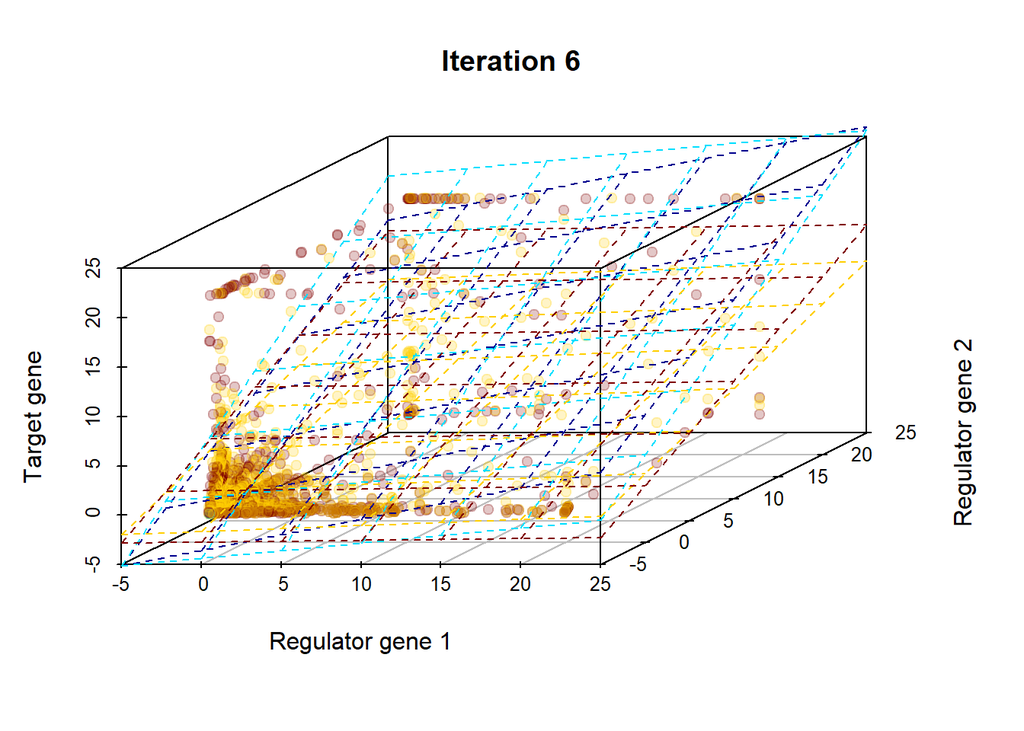

```
## [1] "Comparing with iteration 5"
## [1] "Cell clustering from iteration same as some previous iteration. Exiting."
## [1] "RI of 1 when comparing iteration 6 to iteration 5"
```

and plot stuff

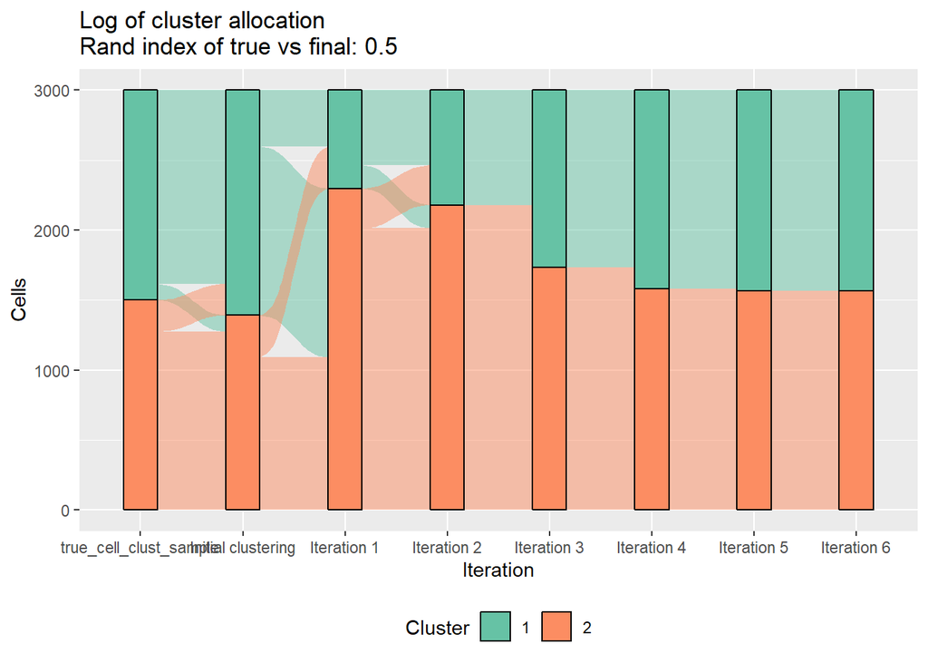

```r
plot_cluster_history(cell_cluster_history = cbind( true_cell_clust_sample, cell_cluster_history))
```